# Introduction to R and Some Best Practices Suggestions

2019-09-20

## What are R and RStudio?

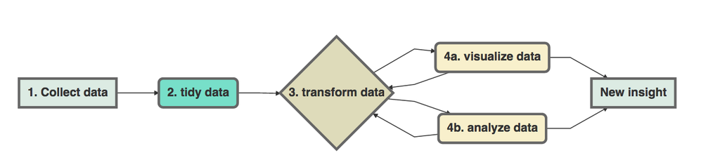

Data Analysis Pipeline, Joseph V. Casillas.

> It is often said that 80% of data analysis is spent on the process of cleaning and preparing the data. (Dasu and Johnson, 2003)

### What is tidy data?

- every column in your dataframe represents a variable
- every row represents an observation
- also known as long format

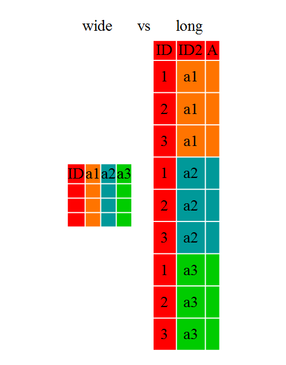

Wide (untidy) vs. long (tidy) data, example from Software Carpentry.

As researcher, you are probably used to using the “wide” format, where each row is often a site/ subject/ patient, and you have multiple observation variables containing the same type of data. Data input may be simpler in the wide format and definitely easier for human eyeballs.

### Why do we need tidy data?

- easy to manipulate (variable are easy to access as vectors)
- easy to visualize
- easy to model
- hard for human eyeballs, but easy for computation

> If you are struggling to make a figure, for example, stop and think hard about whether your data is tidy. Untidiness is a common, often overlooked cause of agony in data analysis and visualization. (Jenny Bryan, STAT545)

### Example of untidy data (Jenny Bryan, STAT545)

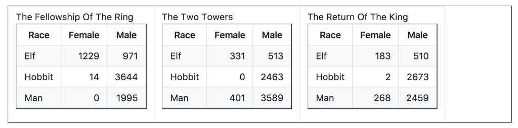

Untidy data, Jenny Bryan.

### Why are these examples of untidy data?

- What’s the total number of words spoken by male hobbits in all three movies?
- Is there a more talkative `Race`?

### How do we turn these tables into a tidy dataframe?

Let’s load our required packages:

```r
library(tidyverse)
```

Let’s read these dataframes in:

```r
fship <- read_csv(here("data", "The_Fellowship_Of_The_Ring.csv"))

ttow <- read_csv(here("data", "The_Fellowship_Of_The_Ring.csv"))

rking <- read_csv(here("data", "The_Fellowship_Of_The_Ring.csv"))
```

Collect untidy dataframes into one dataframe:

```r
lotr_untidy <- dplyr::bind_rows(fship, ttow, rking)
```

This dataframe is still untidy because “word count” is spread out between two columns, `Male` and `Female`. So to make this dataframe tidy, we need to:

- `gather()` up the word counts into one column
- create a new column for `Gender`

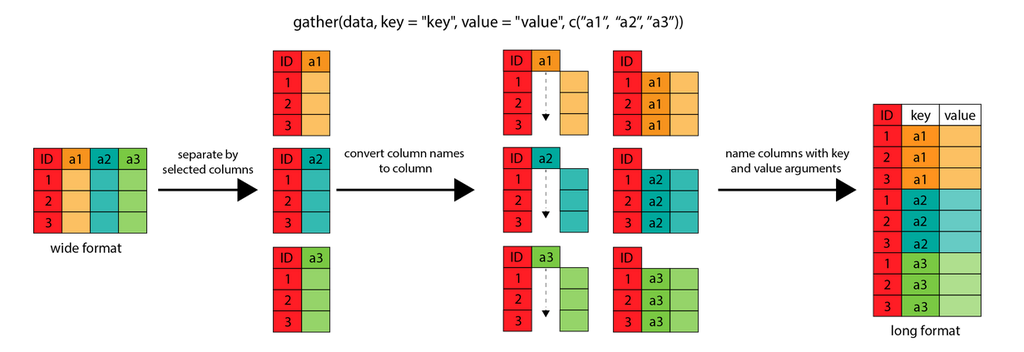

How gather works, example from Software Carpentry.

Time to make this dataframe tidy!

```r
lotr_tidy <- lotr_untidy %>%
  gather(key = 'Gender', value = 'Words', Female, Male)

lotr_tidy
```

```
# A tibble: 18 x 4
   Film                       Race   Gender Words
   <chr>                      <chr>  <chr>  <dbl>
 1 The Fellowship Of The Ring Elf    Female  1229
 2 The Fellowship Of The Ring Hobbit Female    14
 3 The Fellowship Of The Ring Man    Female     0
 4 The Fellowship Of The Ring Elf    Female  1229
 5 The Fellowship Of The Ring Hobbit Female    14
 6 The Fellowship Of The Ring Man    Female     0
 7 The Fellowship Of The Ring Elf    Female  1229
 8 The Fellowship Of The Ring Hobbit Female    14
 9 The Fellowship Of The Ring Man    Female     0
10 The Fellowship Of The Ring Elf    Male     971
11 The Fellowship Of The Ring Hobbit Male    3644
12 The Fellowship Of The Ring Man    Male    1995
13 The Fellowship Of The Ring Elf    Male     971
14 The Fellowship Of The Ring Hobbit Male    3644
15 The Fellowship Of The Ring Man    Male    1995
16 The Fellowship Of The Ring Elf    Male     971
17 The Fellowship Of The Ring Hobbit Male    3644
18 The Fellowship Of The Ring Man    Male    1995
```

Want to see what else you can do with this dataset? Check out Jenny Bryan’s [LOTR GitHub Repo](https://github.com/jennybc/lotr-tidy)!

## Challenge Question 1

`spread()` is another tidyr function that converts a dataframe from the long format to the wide format. How would you convert the `lotr_tidy` dataframe back into the `lotr_untidy` dataframe?

```r
lotr_untidy <- lotr_tidy %>%
   spread(key = "Gender", value = "Words")

lotr_untidy
```

## Challenge Question 2

Let’s use the EDAWR [Expert Data Analysis with R Workshop by RStudio](https://github.com/rstudio/EDAWR) datasets to practice a few more tidyr functionality. We’ve exported the `cases` and `storms` data for you as `.csv` files and they are in the `data` directory.

In the EDAWR dataset, `cases`, we have the number of tuberculosis cases reported in France, Germany and United States from 2011 to 2013. What are the total number of tuberculosis cases reported over three years per country?

```r
cases <- read_csv(here("data", "TB_cases.csv"))
```

SOLUTION:

```r
cases_tidy <- cases %>%
  gather(key = "Year", value = "TB_cases", `2011`:`2013`) %>%
  group_by(country) %>%
  summarise(sum(TB_cases))
```

## Other useful functions from tidyr - Separate and Unite

Let’s use the EDAWR dataset again. This time, we are going to use the `storms` data, which has the maximum wind speeds for six Atlantic hurricanes.

```r
storms <- read_csv(here("data","hurricanes.csv"))
```

`separate()` allows you to separate a column into multiple other columns by using a separator. For example, if we want to separate the `date` column into `year`, `month`, `day`, we can do that by:

```r
storms.sep <- storms %>%
  separate(date, c("year", "month", "day"), sep = "-")
```

## Challenge Question 3

How do you combine the three separate columns, `year`, `month`, `day`, that you just created in `storms.sep` back into one column, `date`? Hint: `unite()` works the opposite way as `separate()`.

```r
storms.unite <- storms.sep %>%
  unite("date", c("year", "month", "day"), sep = "-")
```